# Reproducible Research – Assigment #1

This report shows the solution of homework #1.

## Loading and Preprocessing the Data

We just load the data using read.csv. Please change the working directory to the location where the data is.

```r
setwd("C:/Users/Juan Carlos/Desktop/Reproducible Data/repdata-data-activity")
ds <- read.csv("activity.csv")
summary(ds)
```

```
##      steps               date          interval
##  Min.   :  0.0   2012-10-01:  288   Min.   :   0
##  1st Qu.:  0.0   2012-10-02:  288   1st Qu.: 589
##  Median :  0.0   2012-10-03:  288   Median :1178
##  Mean   : 37.4   2012-10-04:  288   Mean   :1178
##  3rd Qu.: 12.0   2012-10-05:  288   3rd Qu.:1766
##  Max.   :806.0   2012-10-06:  288   Max.   :2355
##  NA's   :2304    (Other)   :15840
```

## Calculation of Total Number of Steps per Day

```r
require(plyr)
ds1 <- ds[complete.cases(ds),]
summary(ds1)
```

```
##      steps               date          interval
##  Min.   :  0.0   2012-10-02:  288   Min.   :   0
##  1st Qu.:  0.0   2012-10-03:  288   1st Qu.: 589
##  Median :  0.0   2012-10-04:  288   Median :1178
##  Mean   : 37.4   2012-10-05:  288   Mean   :1178
##  3rd Qu.: 12.0   2012-10-06:  288   3rd Qu.:1766
##  Max.   :806.0   2012-10-07:  288   Max.   :2355
##                  (Other)   :13536
```

```r
dd2 <- ddply(ds1,~date,summarise,steps=sum(steps))
```

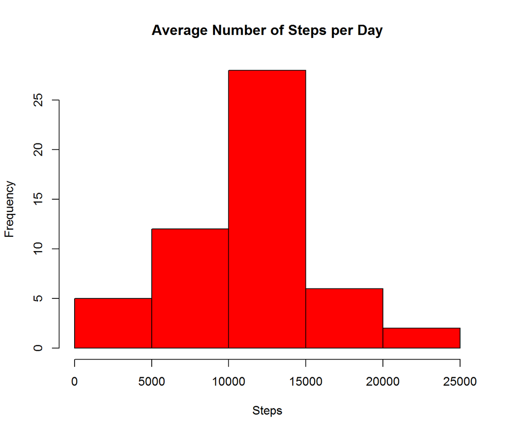

```r
hist(dd2$steps,main = "Average Number of Steps per Day", xlab = "Steps", col="red")
```

The mean and median of steps per day are:

```r
mean(dd2$steps)
```

```
## [1] 10766
```

```r
median(dd2$steps)
```

```
## [1] 10765
```

## Calculation of the Average Daily Activity Pattern

```r
require(plyr)
dd3 <- ddply(ds1,~interval,summarise,steps=mean(steps))
```

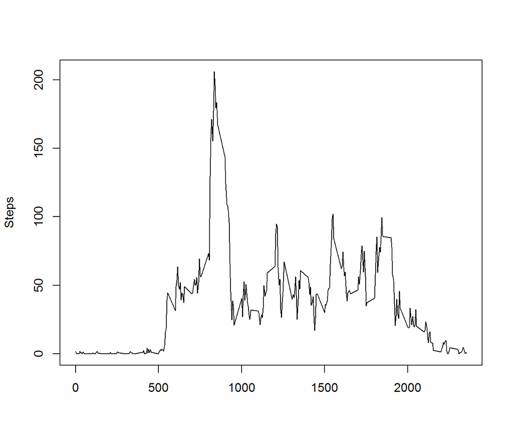

```r
with(dd3, plot(interval, steps, type = "l",ylab = "Steps", xlab = ""))
```

The following calculation finds the interval with maximum average number of steps. It specifies the 5-minute interval and the number of steps (i.e., the maximum for any given interval):

```r
dd3[which.max(dd3$steps),]
```

```
##     interval steps
## 104      835 206.2
```

## Imputing missing values

The following is the number of rows with “missing values”, i.e., the number of rows with “incomplete cases”.

```r
(dim(ds)-dim(ds1))[1]
```

```
## [1] 2304
```

```r
dd4 <- ds1
dd4$steps <- ifelse(is.na(dd4$steps), 0, dd4$steps)
dd5 <- ddply(dd4,~date,summarise,steps=sum(steps))
```

```r
mean(dd5$steps)
```

```
## [1] 10766
```

```r
median(dd5$steps)
```

```
## [1] 10765
```

## Calculation of the new graph

the new graph is identical to the previous one.

```r
require(plyr)
dd6 <- ddply(dd4,~interval,summarise,steps=mean(steps))
```

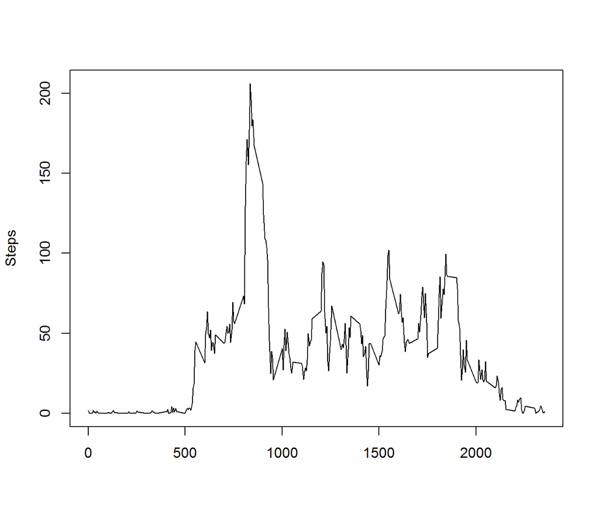

```r
with(dd6, plot(interval, steps, type = "l",ylab = "Steps", xlab = ""))
```

dd4$datetype now contains two factors: weekday and weekend, depending on the type of day in date.

```r
dd4$datetype <- ifelse(weekdays(as.Date(dd4$date))%in% c('Saturday','Sunday'),"weekend","weekday")
```

The next steps are to generate the graph for each factor.

```r
dd6 <- ddply(dd4,~interval+datetype,summarise,steps=mean(steps))
```

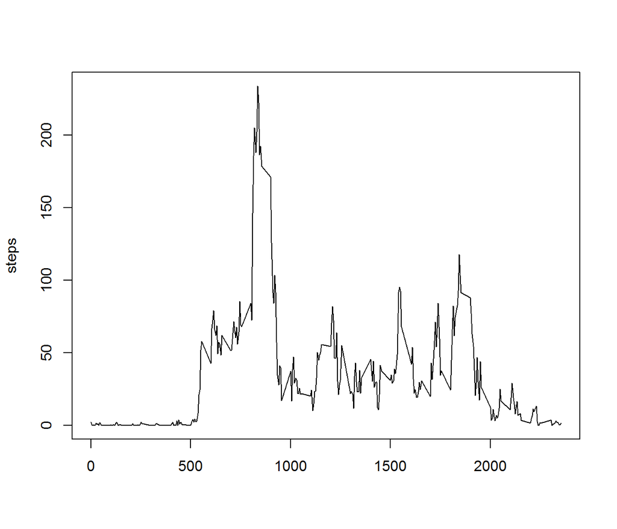

```r
with(dd6, plot(steps ~ interval, subset = datetype == "weekday", type = "l",ylab = "steps", xlab = ""))
```

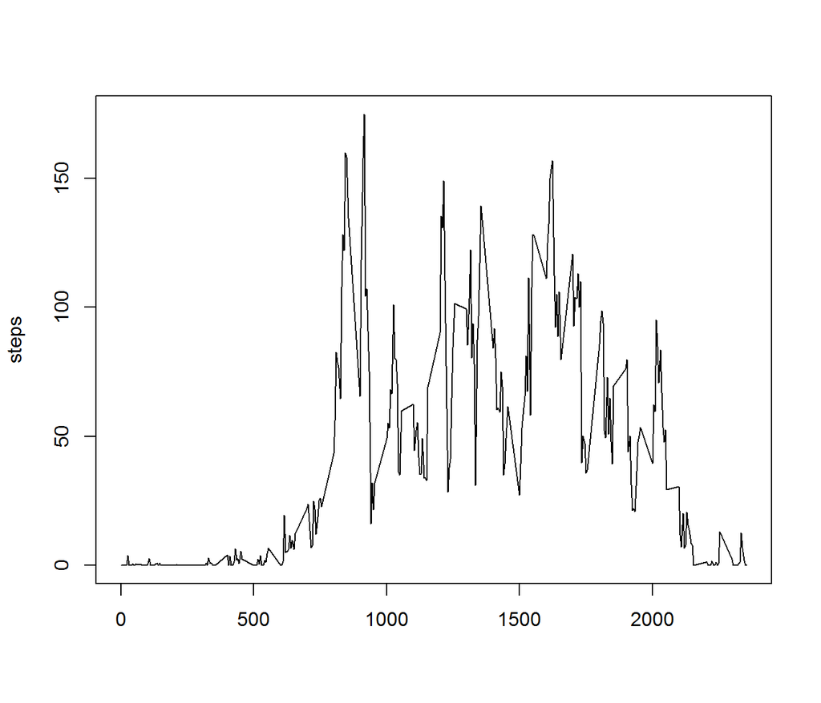

```r
with(dd6, plot(steps ~ interval, subset = datetype == "weekend", type = "l",ylab = "steps", xlab = ""))
```